# Disaster Relief Project: Part 2

# 4 Final Conclusions

```r
CV_perf_table
```

```
#>               Model                                 Tuning     AUROC Threshold
#> 1           Log Reg                                    N/A 0.9703728     > 0.1
#> 2               KNN                                     10 0.9962753     > 0.1
#> 3 Penalized Log Reg alpha = 0.65 and lambda = 6.416034e-06 0.9959100     > 0.1
#> 4               SVM                   gamma = 4 cost = 100 0.9968717       N/A
#> 5       Naive Bayes                                   <NA>        NA      <NA>
#> 6               LDA                                   <NA>        NA      <NA>
#> 7               QDA                                   <NA>        NA      <NA>
#> 8    Random Forests                                   <NA>        NA      <NA>
#> 9     Boosted Trees                                   <NA>        NA      <NA>
#>    Accuracy       TPR       FPR Precision
#> 1 0.9906388 0.9487179 0.9920277 0.7976783
#> 2 0.9974700 0.9950000 0.9975506 0.9950000
#> 3 0.9920000 1.0000000 0.9918200 1.0000000
#> 4 0.9940000 1.0000000 1.0000000 0.8723404
#> 5        NA        NA        NA        NA
#> 6        NA        NA        NA        NA
#> 7        NA        NA        NA        NA
#> 8        NA        NA        NA        NA
#> 9        NA        NA        NA        NA
```

## 4.1 Threshold Justification

The Threshold chosen for the logistic regression, KNN, and penalized logistic regression models was chosen to be > 0.1. This threshold was chosen because the out put of all of my predictors were all estimated probabilities with positive probabilities scoring the highest and negative probabilities scoring the lowest so having a probability of 0.1 made sure that I was setting a threshold that could collect the most true positives possible.

### 4.1.1 Conclusion #1

Running the models and going over the results all models perform exceptionally well and are all comparable to each other with accuracies all over 99% with few errors in the way the classified the test data. The one that works the best is the Penalized Logistic Regression (ElasticNet) model, this is due to the fact that that the ElasticNet model goes through a finer tuning process than the other methods as it uses the entire data set through k folds to determine the optimal parameters. The SVM model is tuned through a limited tuning data set that is smaller due to the time it would take to process the entire data set to determine the best parameters. The KNN model does offer a better accuracy but its precision is the lower than the ElasticNet model. The logistic regression scores the worst in accuracy and AUROC.

# 5 PART II

# 6 Model Training

## 6.1 Naive Bayes

```r
# Setting Seed and Creating partitioned data
set.seed(5)
Train.nb <- createDataPartition(Training.Data$Class, p=0.75, list=FALSE)
training.nb <- Training.Data[ Train.nb, ]
testing.nb <- Training.Data[ -Train.nb, ]

# Naive Bayes
train_control <- trainControl(method = "cv", number = 10)

fit.nb.tune <- train(
   x = training.nb[,2:4],
   y = as.factor(training.nb$Class), method = "nb",
   trControl = train_control)

fit.nb.tune
```

```
#> Naive Bayes
#>
#> 47431 samples
#>     3 predictor
#>     2 classes: '0', '1'
#>
#> No pre-processing
#> Resampling: Cross-Validated (10 fold)
#> Summary of sample sizes: 42688, 42688, 42688, 42688, 42688, 42687, ...
#> Resampling results across tuning parameters:
#>
#>   usekernel  Accuracy   Kappa
#>   FALSE      0.9702726  0.1317966
#>    TRUE      0.9782000  0.5861417
#>
#> Tuning parameter 'fL' was held constant at a value of 0
#> Tuning
#>  parameter 'adjust' was held constant at a value of 1
#> Accuracy was used to select the optimal model using the largest value.
#> The final values used for the model were fL = 0, usekernel = TRUE and adjust
#>  = 1.
```

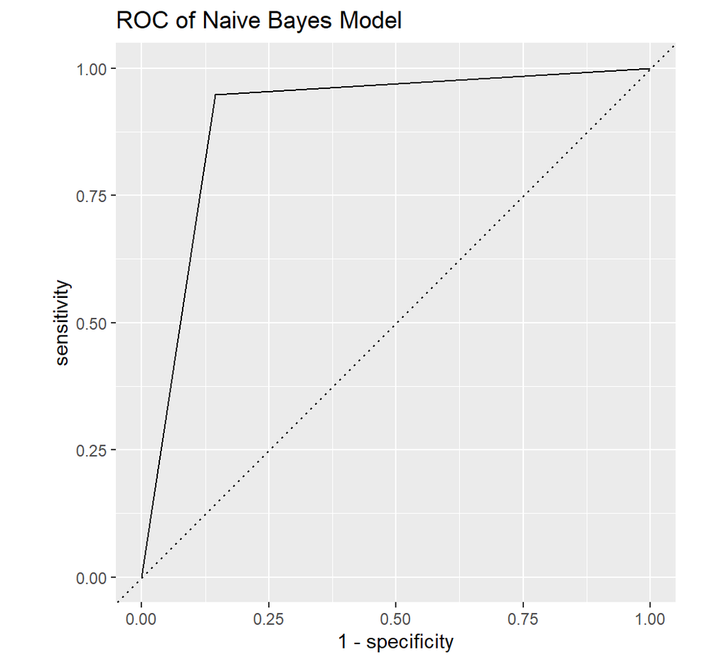

```r
pred.nb.tune <- predict(fit.nb.tune, testing.nb[,-1], type="prob")
pred.nb.1.prob <- pred.nb.tune[,2]

# Setting Threshhold for predicted values.
pred.nb.1 <- ifelse(pred.nb.1.prob > 0.1,1,0)
# Creating Confusion Matrix with predicted and test values.
conf_matrix.nb <- caret::confusionMatrix(table(pred.nb.1,(testing.nb$Class)))
# Creating ROC Curve built from out of sample data
ROC.nb = tibble(truth = factor(testing.nb$Class, levels =c(1,0)), pred.nb.1) %>%
  yardstick::roc_curve(truth, pred.nb.1)

ROC.nb %>%
ggplot(aes(1-specificity, sensitivity)) + geom_line() +
geom_abline(lty=3) +
coord_equal() + ggtitle("ROC of Naive Bayes Model")
```

```r
# Computing AUROC for the Predicted values for Logistic Regression.
AUROC.nb <- yardstick::roc_auc_vec(factor(testing.nb$Class, 1:0), pred.nb.1)

# Naive Bayes Accuracy.
acc.nb <- conf_matrix.nb$overall
acc.nb <- as.numeric(acc.nb[1])

# Naive Bayes TPR and FPR.
TPR.nb <- ROC.nb[3,3]
FPR.nb <- ROC.nb[3,2]

# Naive Bayes Precision.
precision.nb <- (conf_matrix.nb$table[4]) / (conf_matrix.nb$table[4]+conf_matrix.nb$table[2])

CV_perf_table[5, 2] = "kernel = TRUE"
CV_perf_table[5, 3] = AUROC.nb
CV_perf_table[5, 4] = "> 0.1"
CV_perf_table[5, 5] = acc.nb
CV_perf_table[5, 6] = TPR.nb
CV_perf_table[5, 7] = FPR.nb
CV_perf_table[5, 8] = precision.nb
```

## 6.2 LDA (Linear Discriminant Analysis)

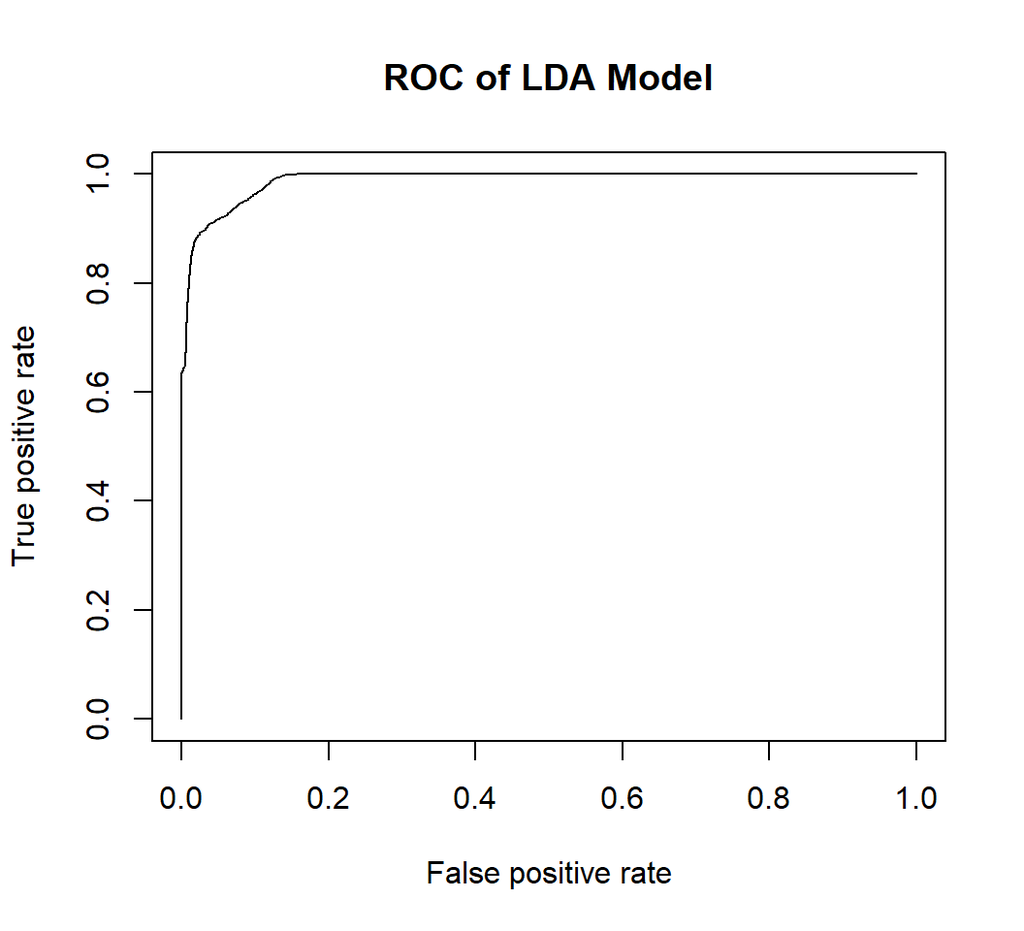

```r
set.seed(2020)
K = 10
eval <- tibble()
folds = rep(1:K, length=nrow(Training.Data)) %>% sample()

for(k in 1:K){
test = (folds == k)
train = (folds != k)
fit.LDA <- lda(Class ~., data = Training.Data[train,])
fit.LDA.predict <- predict(fit.LDA, Training.Data[test, ], type = "prob")
output = tibble(truth = Training.Data[test,1],
                 predictions = fit.LDA.predict$posterior)
eval <- rbind(eval, output)
}

# Predicting Results
pred.LDA <- eval$predictions
pred.LDA.thresh <- ifelse(eval$predictions > 0.1,1,0)
conf_matrix.LDA <- caret::confusionMatrix(table((pred.LDA.thresh[,2]), as.factor(eval$truth)))

roc.LDA <- prediction(pred.LDA[,2], eval$truth)

perf.LDA <- performance(roc.LDA,"tpr","fpr")

AUROC.LDA <- performance(roc.LDA, measure = "auc")

AUROC.LDA <- AUROC.LDA@y.values

plot(perf.LDA, main = "ROC of LDA Model")
```

```r
acc.LDA <- conf_matrix.LDA$overall
acc.LDA <- as.numeric(acc.LDA[1])

TPR.LDA <- (conf_matrix.LDA$table[4])/(conf_matrix.LDA$table[4]+conf_matrix.LDA$table[3])
FPR.LDA <- (conf_matrix.LDA$table[2])/(conf_matrix.LDA$table[1]+conf_matrix.LDA$table[2])

precision.LDA <- (conf_matrix.LDA$table[4]) / (conf_matrix.LDA$table[4]+conf_matrix.LDA$table[2])

CV_perf_table[6, 2] = "N/A"
CV_perf_table[6, 3] = AUROC.LDA
CV_perf_table[6, 4] = "> 0.1"
CV_perf_table[6, 5] = acc.LDA
CV_perf_table[6, 6] = TPR.LDA
CV_perf_table[6, 7] = FPR.LDA
CV_perf_table[6, 8] = precision.LDA
```

## 6.3 QDA (Quadratic Discriminant Analysis)

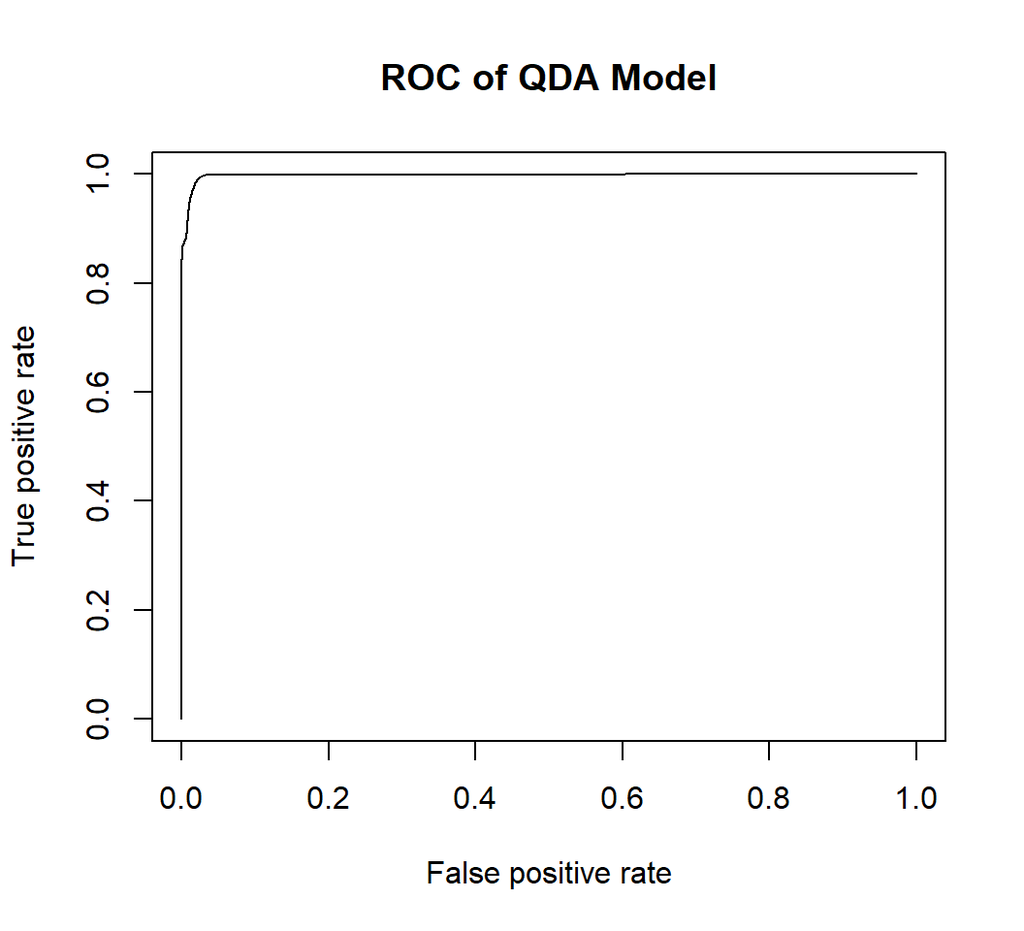

```r
set.seed(2020)
K = 10
eval <- tibble()
folds = rep(1:K, length=nrow(Training.Data)) %>% sample()

for(k in 1:K){
test = (folds == k)
train = (folds != k)
fit.QDA <- qda(Class ~., data = Training.Data[train,])
fit.QDA.predict <- predict(fit.QDA, Training.Data[test, ], type = "prob")
output = tibble(truth = Training.Data[test,1],
                 predictions = fit.QDA.predict$posterior)
eval <- rbind(eval, output)
}

# Predicting Results
pred.QDA <- eval$predictions
pred.QDA.thresh <- ifelse(eval$predictions > 0.1,1,0)
conf_matrix.QDA <- caret::confusionMatrix(table((pred.QDA.thresh[,2]), as.factor(eval$truth)))

roc.QDA <- prediction(pred.QDA[,2], eval$truth)

perf.QDA <- performance(roc.QDA,"tpr","fpr")

AUROC.QDA <- performance(roc.QDA, measure = "auc")

AUROC.QDA <- AUROC.QDA@y.values

plot(perf.QDA, main = "ROC of QDA Model")
```

```r
acc.QDA <- conf_matrix.QDA$overall
acc.QDA <- as.numeric(acc.QDA[1])

TPR.QDA <- (conf_matrix.QDA$table[4])/(conf_matrix.QDA$table[4]+conf_matrix.QDA$table[3])
FPR.QDA <- (conf_matrix.QDA$table[2])/(conf_matrix.QDA$table[1]+conf_matrix.QDA$table[2])

precision.QDA <- (conf_matrix.QDA$table[4]) / (conf_matrix.QDA$table[4]+conf_matrix.QDA$table[2])

CV_perf_table[7, 2] = "N/A"
CV_perf_table[7, 3] = AUROC.QDA
CV_perf_table[7, 4] = "> 0.1"
CV_perf_table[7, 5] = acc.QDA
CV_perf_table[7, 6] = TPR.QDA
CV_perf_table[7, 7] = FPR.QDA
CV_perf_table[7, 8] = precision.QDA
```

## 6.4 Random Forests

```r
if(.Platform$OS.type == "windows") withAutoprint({
memory.size()
memory.size(TRUE)
memory.limit()
})
```

```
#> > memory.size()
#> [1] 419.79
#> > memory.size(TRUE)
#> [1] 814.44
#> > memory.limit()
#> [1] 7937
```

```r
memory.limit(size=56000)
```

```
#> [1] 56000
```

```r
# Random Forest
x <- Training.Data[,2:4]
y <- as.factor(Training.Data[,1])
ntree=1000
metric <- "Accuracy"

# Tuning for optimal mtry
control <- trainControl(method="cv", number=2, search="random")
tunegrid <- expand.grid(.mtry=c(1:3))
rf <- train(x = x, y = y, method="rf", tuneLength=1, metric = metric, tuneGrid = tunegrid, trControl=control, ntree=ntree)
print(rf)
```

```
#> Random Forest
#>
#> 63241 samples
#>     3 predictor
#>     2 classes: '0', '1'
#>
#> No pre-processing
#> Resampling: Cross-Validated (2 fold)
#> Summary of sample sizes: 31621, 31620
#> Resampling results across tuning parameters:
#>
#>   mtry  Accuracy   Kappa
#>   1     0.9967426  0.9469743
#>   2     0.9966952  0.9464968
#>   3     0.9964738  0.9430498
#>
#> Accuracy was used to select the optimal model using the largest value.
#> The final value used for the model was mtry = 1.
```

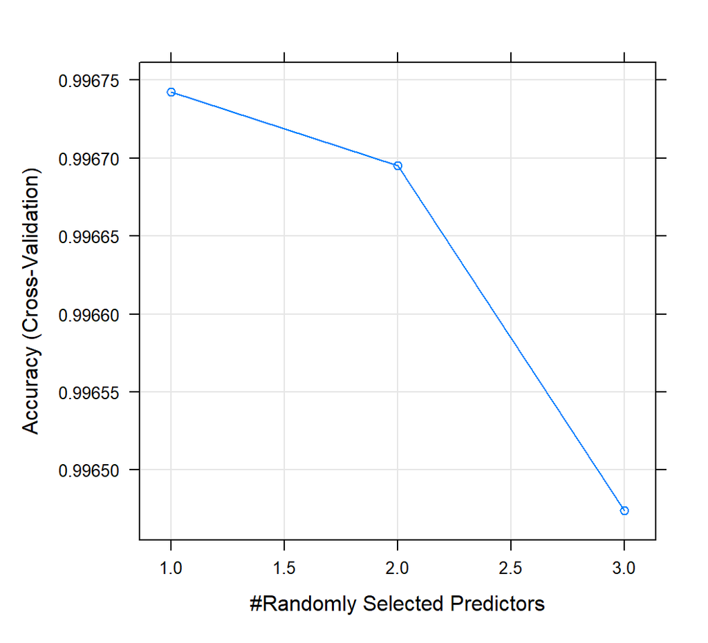

```r
plot(rf)
```

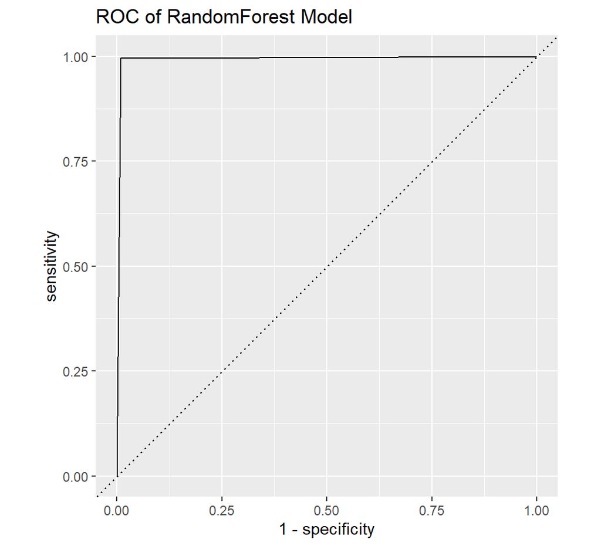

```r
opt.mtry <- rf$bestTune
opt.mtry <- opt.mtry$mtry

# Setting up 10-fold Cross-Validation method Using optimal mtry
set.seed(2020)
K = 10
eval <- tibble()
folds = rep(1:K, length=nrow(Training.Data)) %>% sample()

for(k in 1:K){
test = (folds == k)
train = (folds != k)
rf.opt <- randomForest(as.factor(Class) ~ ., data=Training.Data[train, ],
                       ntree=ntree,
                       mtry = opt.mtry)
rf.opt.predict <- predict(rf.opt, Training.Data[test, ], type = "prob")
output = tibble(truth = Training.Data[test,1],
                 predictions = rf.opt.predict[,2])
eval <- rbind(eval, output)
}

# Predicting Results
pred.rf <- ifelse(eval$predictions > 0.1,1,0)
conf_matrix.rf <- caret::confusionMatrix(table(pred.rf,(eval$truth)))

ROC.rf = tibble(truth = factor(eval$truth, levels =c(1,0)), pred.rf) %>%
  yardstick::roc_curve(truth, pred.rf)

ROC.rf %>%
ggplot(aes(1-specificity, sensitivity)) + geom_line() +
geom_abline(lty=3) +
coord_equal() + ggtitle("ROC of RandomForest Model")
```

```r
AUROC.rf <- yardstick::roc_auc_vec(factor(eval$truth, 1:0), pred.rf)

acc.rf <- conf_matrix.rf$overall
acc.rf <- as.numeric(acc.rf[1])

TPR.rf <- ROC.rf[3,3]
FPR.rf <- ROC.rf[3,2]

precision.rf <- (conf_matrix.rf$table[4]) / (conf_matrix.rf$table[4]+conf_matrix.rf$table[2])

CV_perf_table[8, 2] = "opt.mtry = 1"
CV_perf_table[8, 3] = AUROC.rf
CV_perf_table[8, 4] = "> 0.1"
CV_perf_table[8, 5] = acc.rf
CV_perf_table[8, 6] = TPR.rf
CV_perf_table[8, 7] = FPR.rf
CV_perf_table[8, 8] = precision.rf
```

## 6.5 Boosted Trees

```r
# Boosted Trees
set.seed(12)
shrink = seq(.001, 0.1, by = 0.049)
MSE = matrix(NA, 3, 2)
MSE[,1] = seq(.001, 0.1, by = 0.049)

Train <- createDataPartition(Training.Data$Class, p=0.75, list=FALSE)
training.bt <- Training.Data[ Train, ]
testing.bt <- Training.Data[ -Train, ]


# train GBM model

for (i in 1:length(shrink)){
gbm.fit.1 <- gbm(
  formula = as.factor(Class) ~ .,
  distribution = "gaussian",
  data = training.bt,
  n.trees = 1000,
  interaction.depth = 1,
  shrinkage = shrink,
  cv.folds = 3,
  n.cores = NULL,
  verbose = FALSE
  )
min_MSE <- which.min(gbm.fit.1$cv.error)
MSE[i,2] <- sqrt(gbm.fit.1$cv.error[min_MSE])
}

MSE <- as.data.frame(MSE)
row <- which.min(MSE$V2)
shrinkage <- MSE[row,1]

gbm.fit.2 <- gbm(
  formula = as.factor(Class) ~ .,
  distribution = "gaussian",
  data = training.bt,
  n.trees = 10000,
  interaction.depth = 1,
  shrinkage = shrinkage,
  cv.folds = 3,
  n.cores = NULL,
  verbose = FALSE
  )

n.trees <- gbm.perf(gbm.fit.2, method = "cv")
```

[figure not shown]

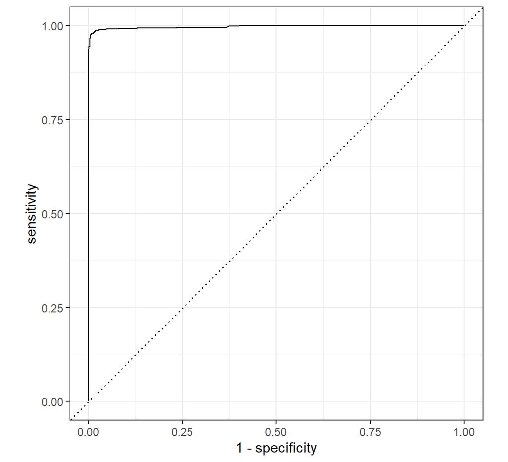

```r
gbm.fit.3 <- gbm(
  formula = as.factor(Class) ~ .,
  distribution = "gaussian",
  data = training.bt,
  n.trees = n.trees,
  interaction.depth = 1,
  shrinkage = shrinkage,
  cv.folds = 10,
  n.cores = NULL,
  verbose = FALSE
  )

# Predicting Results
pred.bt <- predict(gbm.fit.3, testing.bt, n.trees=n.trees, type = "link")
pred.bt <- rescale(pred.bt)
pred.bt <- as.data.frame(pred.bt)
pred.bt <- (1 - pred.bt)
pred.bt.thresh <- ifelse(pred.bt > 0.1,1,0)
pred.boost <- tibble(testing.bt$Class, pred.bt)
names(pred.boost)[1] <- "Truth"

conf_matrix.bt <- caret::confusionMatrix(table(pred.bt.thresh,(testing.bt$Class)))

autoplot(roc_curve(pred.boost, truth = factor(Truth), predictions = pred.bt), title = "Boosted Tree ROC Curve")
```

```r
AUROC.bt <- yardstick::roc_auc_vec(factor(pred.boost$Truth), pred.boost$pred.bt)

acc.bt <- (conf_matrix.bt$table[4]+conf_matrix.bt$table[1])/(conf_matrix.bt$table[1]+conf_matrix.bt$table[2]+conf_matrix.bt$table[4]+conf_matrix.bt$table[3])
acc.bt <- (1 - acc.bt)

TPR.bt <- (conf_matrix.bt$table[4])/(conf_matrix.bt$table[4]+conf_matrix.bt$table[3])
FPR.bt <- (conf_matrix.bt$table[2])/(conf_matrix.bt$table[1]+conf_matrix.bt$table[2])

precision.bt <- (conf_matrix.bt$table[4]) / (conf_matrix.bt$table[4]+conf_matrix.bt$table[3])

CV_perf_table[9, 2] = "n.trees = 9990 & shrinkage = 0.05"
CV_perf_table[9, 3] = AUROC.bt
CV_perf_table[9, 4] = "> 0.1"
CV_perf_table[9, 5] = acc.bt
CV_perf_table[9, 6] = TPR.bt
CV_perf_table[9, 7] = FPR.bt
CV_perf_table[9, 8] = precision.bt
```

## 6.6 Threshold Selection

The Thresholds were all set to > 0.1, the reasoning for this was because I would rather have more false more false positives then false negatives if it meant making sure that all the make shift shelters were located and that the displaced people can be delivered food and water as quickly as possible.

# 7 Results (Cross-Validation)

## 7.1 Performance Table

```r
CV_perf_table
```

```
#>               Model                                 Tuning     AUROC Threshold
#> 1           Log Reg                                    N/A 0.9703728     > 0.1
#> 2               KNN                                     10 0.9962753     > 0.1
#> 3 Penalized Log Reg alpha = 0.65 and lambda = 6.416034e-06 0.9959100     > 0.1
#> 4               SVM                   gamma = 4 cost = 100 0.9968717       N/A
#> 5       Naive Bayes                          kernel = TRUE 0.9014149     > 0.1
#> 6               LDA                                    N/A 0.9888501     > 0.1
#> 7               QDA                                    N/A 0.9981938     > 0.1
#> 8    Random Forests                           opt.mtry = 1 0.9932661     > 0.1
#> 9     Boosted Trees      n.trees = 9990 & shrinkage = 0.05 0.9971182     > 0.1
#>    Accuracy       TPR         FPR Precision
#> 1 0.9906388 0.9487179 0.992027707 0.7976783
#> 2 0.9974700 0.9950000 0.997550621 0.9950000
#> 3 0.9920000 1.0000000 0.991820041 1.0000000
#> 4 0.9940000 1.0000000 1.000000000 0.8723404
#> 5 0.8576850 0.9481038 0.854725978 0.1759911
#> 6 0.9824639 0.8471810 0.013067838 0.6816554
#> 7 0.9895795 0.9005935 0.007481337 0.7990347
#> 8 0.9911292 0.9955490 0.990983191 0.7847953
#> 9 0.9702087 0.9553753 1.000000000 0.9553753
```

The metrics here were calculated by using parameters (where applicable) that maximized the performance of these models.

## 7.2 ROC Curves

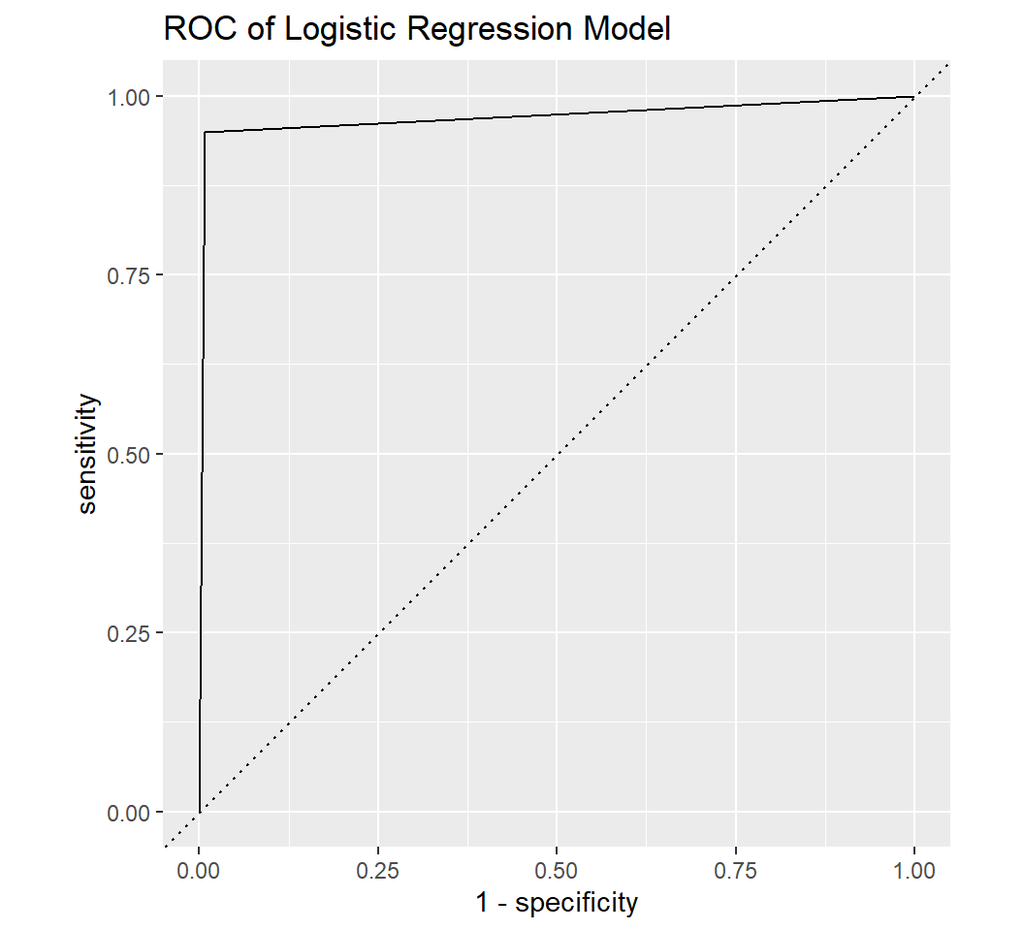

```r
# Logistic Regression ROC Curves
ROC.LR %>%
ggplot(aes(1-specificity, sensitivity)) + geom_line() +
geom_abline(lty=3) +
coord_equal() + ggtitle("ROC of Logistic Regression Model")
```

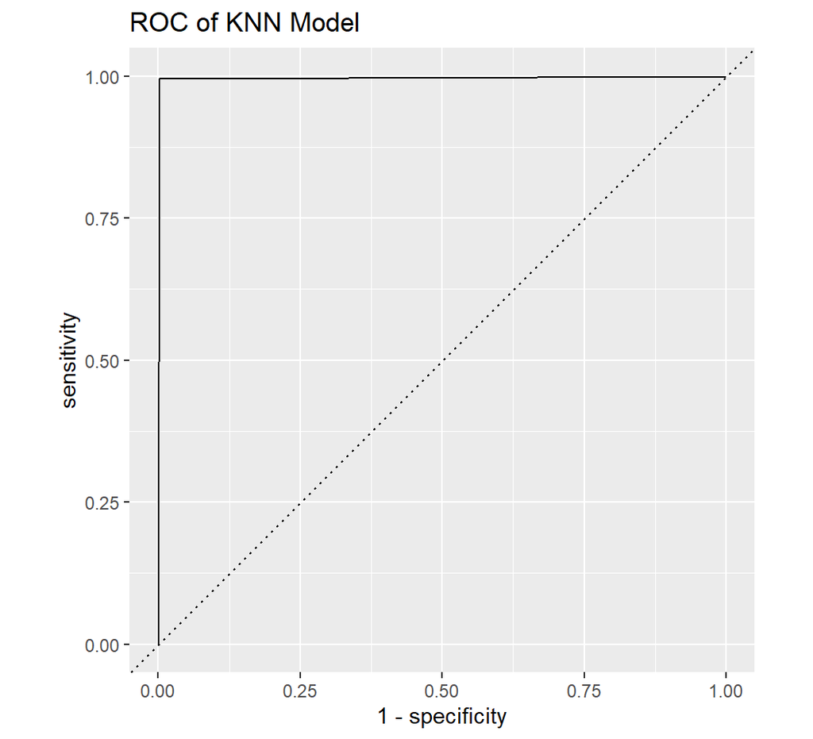

```r
# KNN   ROC Curves
ROC.knn %>%
ggplot(aes(1-specificity, sensitivity)) + geom_line() +
geom_abline(lty=3) +
coord_equal() + ggtitle("ROC of KNN Model")
```

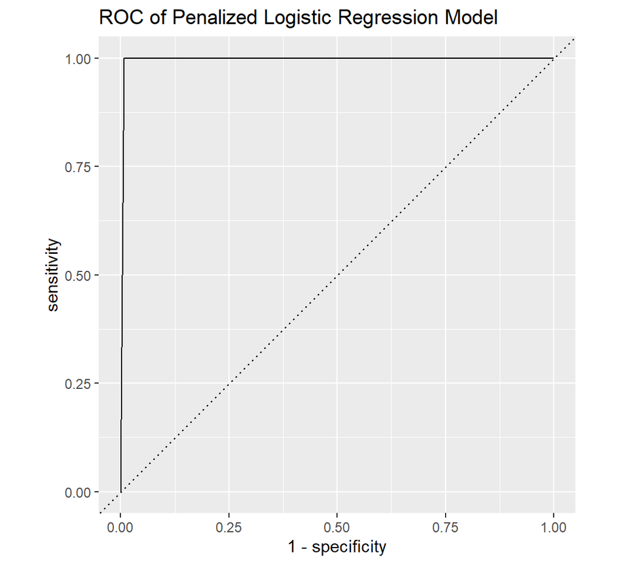

```r
# Penalized Logistic Regression (elastic net penalty) ROC Curve
ROC.EN %>%
ggplot(aes(1-specificity, sensitivity)) + geom_line() +
geom_abline(lty=3) +
coord_equal() + ggtitle("ROC of Penalized Logistic Regression Model")
```

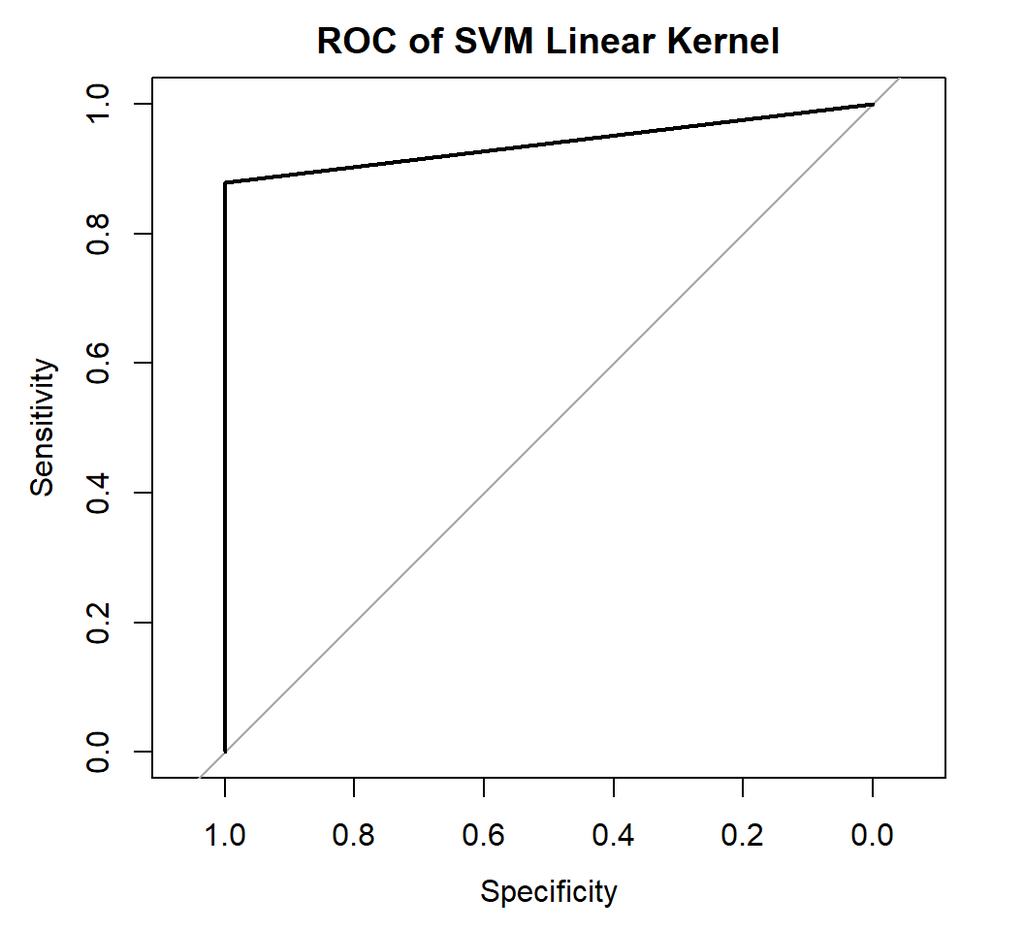

```r
# Support Vector Machine ROC Curve
ROC_line <- plot(line_pROC, main = "ROC of SVM Linear Kernel")
```

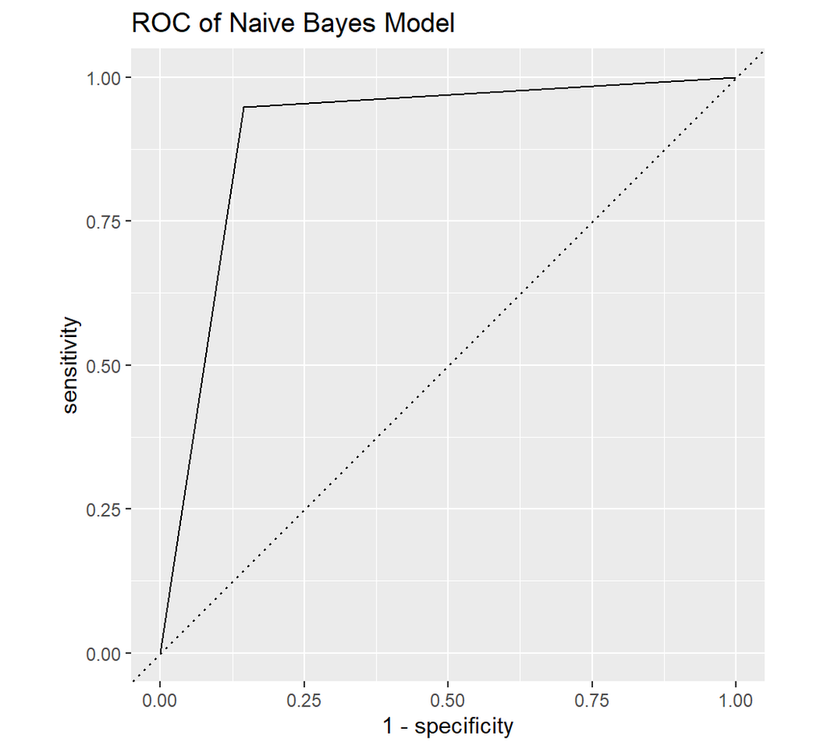

```r
# Naive Bayes ROC Curve
ROC.nb %>%
ggplot(aes(1-specificity, sensitivity)) + geom_line() +
geom_abline(lty=3) +
coord_equal() + ggtitle("ROC of Naive Bayes Model")
```

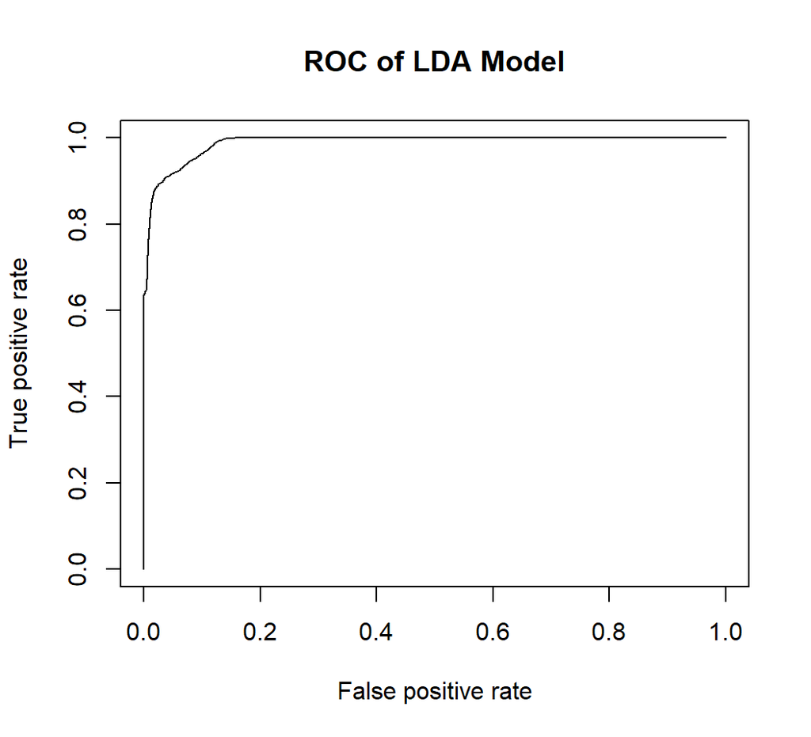

```r
# Linear Discriminant Analysis ROC Curve
plot(perf.LDA, main = "ROC of LDA Model")
```

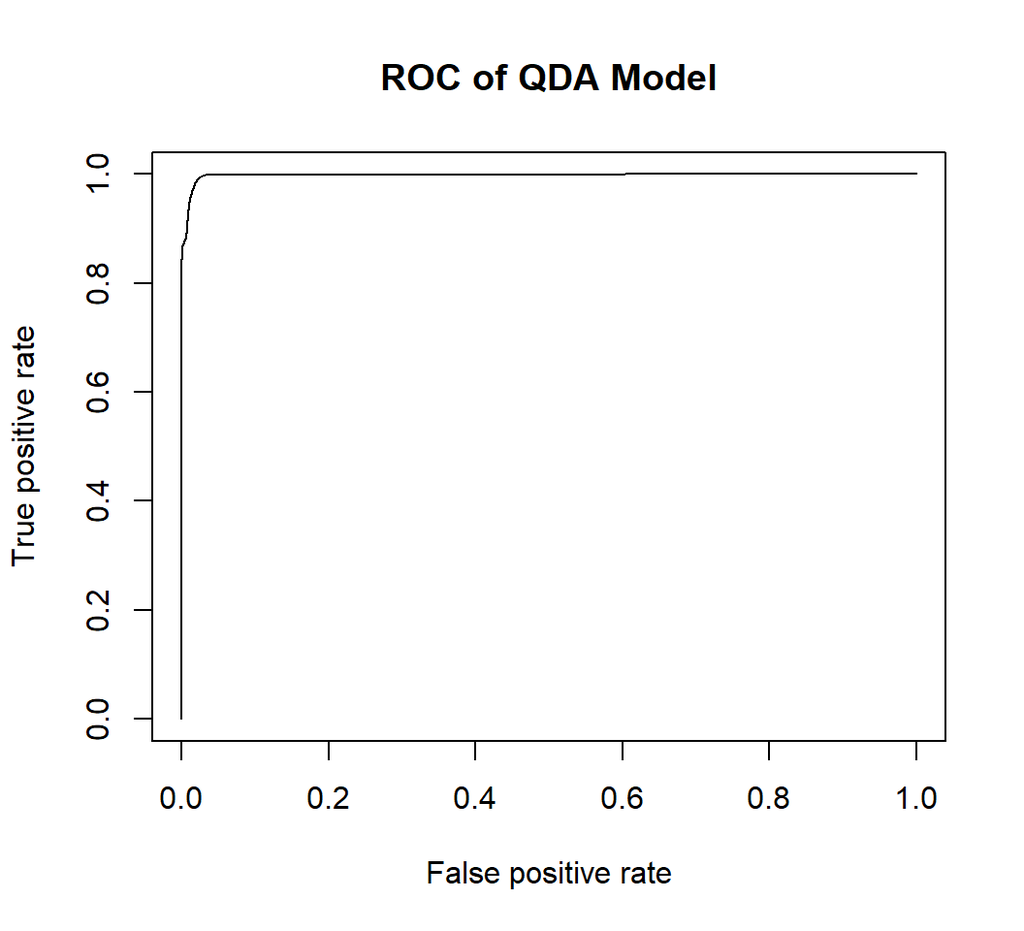

```r
# Quadratic Discriminant Analysis ROC Curve
plot(perf.QDA, main = "ROC of QDA Model")
```

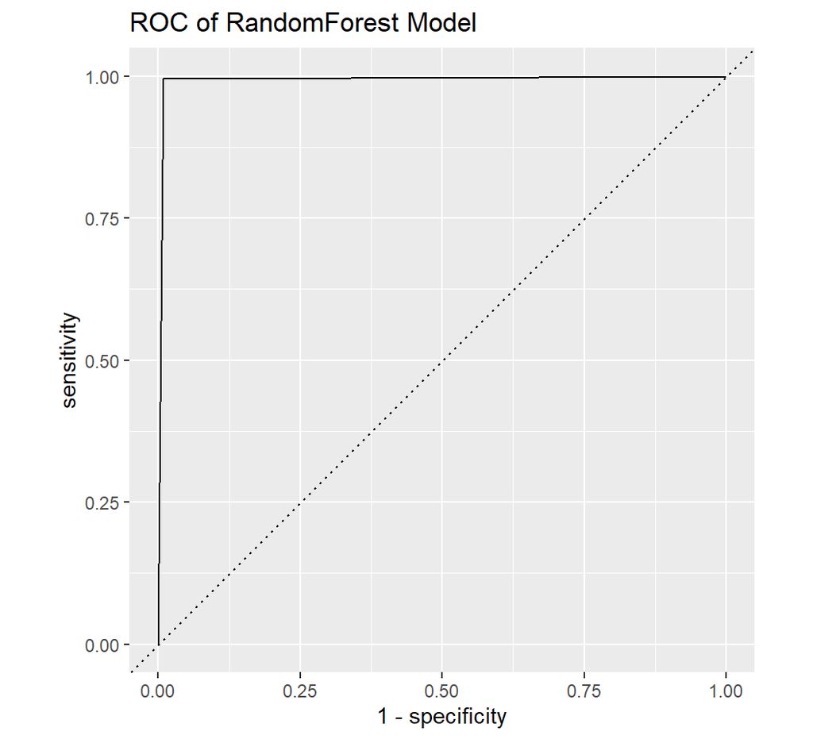

```r
# Random Forests ROC
ROC.rf %>%
ggplot(aes(1-specificity, sensitivity)) + geom_line() +
geom_abline(lty=3) +
coord_equal() + ggtitle("ROC of RandomForest Model")
```

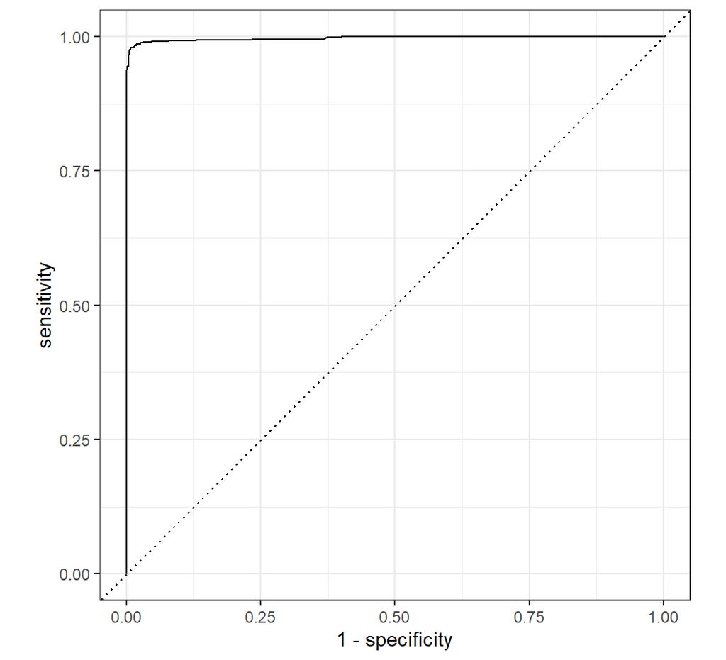

```r
# Boosted Trees
autoplot(roc_curve(pred.boost, truth = factor(Truth), predictions = pred.bt), title = "Boosted Tree ROC Curve")
```

**ADDITIONAL SECTIONS FOR PART II:**

# 8 Hold-out Data / EDA

## 8.1 Hold-out Data

```r
proj_dir = "~/UVA SYS ME/SYS 6018 Data Mining/Project"

ortho057_noblue = read_table(file.path(proj_dir, "orthovnir057_ROI_NON_Blue_Tarps.txt"), skip = 8, col_names = FALSE)
ortho057_noblue = ortho057_noblue[,8:10]
colnames(ortho057_noblue) <- c("Red", "Green", "Blue")
ortho057_noblue = cbind(bluetarp= 0, ortho057_noblue, file = "057_N")

ortho067_blue = read_table(file.path(proj_dir, "orthovnir067_ROI_Blue_Tarps.txt"), skip = 8, col_names = FALSE)
ortho067_blue = ortho067_blue[,8:10]
colnames(ortho067_blue) <- c("Red", "Green", "Blue")
ortho067_blue = cbind(bluetarp= 1, ortho067_blue, file = "067_blue")


ortho067_blue_data = read_table(file.path(proj_dir, "orthovnir067_ROI_Blue_Tarps_data.txt"), skip = 8, col_names = FALSE)
ortho067_blue_data = ortho067_blue_data[,1:3]
colnames(ortho067_blue_data) <- c("Red", "Green", "Blue")
ortho067_blue_data = cbind(bluetarp= 1, ortho067_blue_data, file = "067_blue_data")

ortho067_noblue = read_table(file.path(proj_dir, "orthovnir067_ROI_NOT_Blue_Tarps.txt"), skip = 8, col_names = FALSE)
ortho067_noblue = ortho067_noblue[,8:10]
colnames(ortho067_noblue) <- c("Red", "Green", "Blue")
ortho067_noblue = cbind(bluetarp= 0, ortho067_noblue, file = "067_N")

ortho069_blue = read_table(file.path(proj_dir, "orthovnir069_ROI_Blue_Tarps.txt"), skip = 8, col_names = FALSE)
ortho069_blue = ortho069_blue[,8:10]
colnames(ortho069_blue) <- c("Red", "Green", "Blue")
ortho069_blue = cbind(bluetarp= 1, ortho069_blue, file = "069_blue")

ortho069_noblue = read_table(file.path(proj_dir, "orthovnir069_ROI_NOT_Blue_Tarps.txt"), skip = 8, col_names = FALSE)
ortho069_noblue = ortho069_noblue[,8:10]
colnames(ortho069_noblue) <- c("Red", "Green", "Blue")
ortho069_noblue = cbind(bluetarp= 0, ortho069_noblue, file = "069_N")

ortho078_blue = read_table(file.path(proj_dir, "orthovnir078_ROI_Blue_Tarps.txt"), skip = 8, col_names = FALSE)
ortho078_blue = ortho078_blue[,8:10]
colnames(ortho078_blue) <- c("Red", "Green", "Blue")
ortho078_blue = cbind(bluetarp= 1, ortho078_blue, file = "078_blue")

ortho078_noblue = read_table(file.path(proj_dir, "orthovnir078_ROI_NON_Blue_Tarps.txt"), skip = 8, col_names = FALSE)
ortho078_noblue = ortho078_noblue[,8:10]
colnames(ortho078_noblue) <- c("Red", "Green", "Blue")
ortho078_noblue = cbind(bluetarp= 0, ortho078_noblue, file = "078_N")

df_list <- list(
  ortho057_noblue,
  ortho067_blue,
  ortho067_blue_data,
  ortho067_noblue,
  ortho069_blue,
  ortho069_noblue,
  ortho078_blue,
  ortho078_noblue
  )

HaitiHoldOut_complete <- Reduce(function(x, y) merge(x, y, all=TRUE), df_list)

HaitiHoldOut <- HaitiHoldOut_complete

HaitiHoldOut <- HaitiHoldOut %>%
  relocate(bluetarp, .before = Red) %>%
  subset(select = -c(5))

names(HaitiHoldOut)[1] <- 'Class'

CV_HOO_perf_table <- data.frame(matrix(ncol = 8, nrow = 9))
colnames(CV_HOO_perf_table) <- c("Model", "Tuning", "AUROC", "Threshold", "Accuracy", "TPR", "FPR", "Precision")
CV_HOO_perf_table[1, 1] = "Log Reg"
CV_HOO_perf_table[2, 1] = "KNN"
CV_HOO_perf_table[3, 1] = "Penalized Log Reg"
CV_HOO_perf_table[4, 1] = "SVM"
CV_HOO_perf_table[5, 1] = "Naive Bayes"
CV_HOO_perf_table[6, 1] = "LDA"
CV_HOO_perf_table[7, 1] = "QDA"
CV_HOO_perf_table[8, 1] = "Random Forests"
CV_HOO_perf_table[9, 1] = "Boosted Trees"
```

## 8.2 EDA

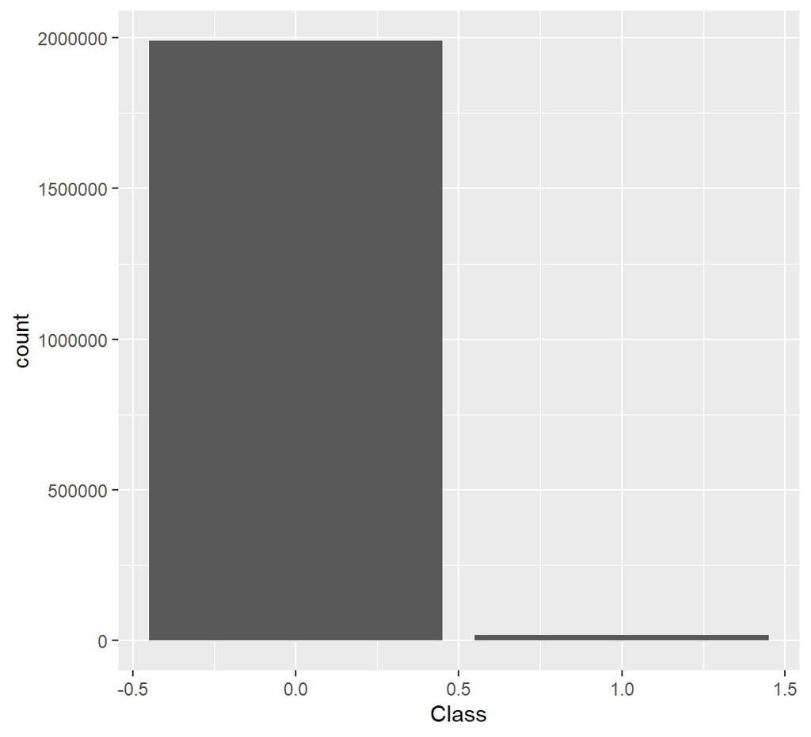

```r
# plot to see count of all the classes
ggplot(data = HaitiHoldOut) +
  geom_bar(mapping = aes(x = Class))
```

```r
# Blue Tarp is the least amount of pixels of any of the classes.
HaitiHoldOut %>%
  count(Class)
```

```
#>   Class       n
#> 1     0 1989697
#> 2     1   18919
```

```r
# Number of classes per each pixel.
by(HaitiHoldOut, HaitiHoldOut$Class, summary)
```

```
#> HaitiHoldOut$Class: 0
#>      Class        Red            Green            Blue
#>  Min.   :0   Min.   : 27.0   Min.   : 28.0   Min.   : 25.00
#>  1st Qu.:0   1st Qu.: 76.0   1st Qu.: 70.0   1st Qu.: 55.00
#>  Median :0   Median :107.0   Median : 91.0   Median : 66.00
#>  Mean   :0   Mean   :118.3   Mean   :105.2   Mean   : 81.76
#>  3rd Qu.:0   3rd Qu.:139.0   3rd Qu.:116.0   3rd Qu.: 87.00
#>  Max.   :0   Max.   :255.0   Max.   :255.0   Max.   :255.00
#> ------------------------------------------------------------
#> HaitiHoldOut$Class: 1
#>      Class        Red            Green            Blue
#>  Min.   :1   Min.   : 48.0   Min.   : 56.0   Min.   : 57
#>  1st Qu.:1   1st Qu.: 82.0   1st Qu.:102.0   1st Qu.:126
#>  Median :1   Median :110.0   Median :131.0   Median :162
#>  Mean   :1   Mean   :112.2   Mean   :135.8   Mean   :168
#>  3rd Qu.:1   3rd Qu.:134.0   3rd Qu.:163.0   3rd Qu.:210
#>  Max.   :1   Max.   :255.0   Max.   :255.0   Max.   :255
```

```r
# looking at all the summaries of each Class.
```

# 9 Results (Hold-Out)

## 9.1 Logistic Regression Hold-Out

```r
# Using trained model to predict values on Hold-Out (HOO) Data.
pred.LR.HOO <- predict(mod_fitcv, newdata = HaitiHoldOut[, 2:4])
# Setting Threshhold for predicted values.
pred.LR.HOO <- ifelse(pred.LR.HOO > 0.1,1,0)
# Creating Confusion Matrix with predicted and test values.
conf_matrix.LR.HOO <- caret::confusionMatrix(table(pred.LR.HOO,(HaitiHoldOut$Class)))
# Creating ROC Curve built from out of sample data
ROC.LR.HOO = tibble(truth = factor(HaitiHoldOut$Class, levels =c(1,0)), pred.LR.HOO) %>%
  yardstick::roc_curve(truth, pred.LR.HOO)

# Computing AUROC for the Predicted values for Logistic Regression.
AUROC.LR.HOO <- yardstick::roc_auc_vec(factor(HaitiHoldOut$Class, 1:0), pred.LR.HOO)

# Logistic Regression Accuracy.
acc.LR.HOO <- conf_matrix.LR.HOO$overall
acc.LR.HOO <- as.numeric(acc.LR.HOO[1])

# Logistic Regression TPR and FPR.
TPR.LR.HOO <- ROC.LR.HOO[3,3]
FPR.LR.HOO <- ROC.LR.HOO[3,2]

# Logistic Regression Precision.
precision.LR.HOO <- (conf_matrix.LR.HOO$table[4]) / (conf_matrix.LR.HOO$table[4]+conf_matrix.LR.HOO$table[2])

# Adding values to Performance Table
CV_HOO_perf_table[1, 2] = "N/A"
CV_HOO_perf_table[1, 3] = AUROC.LR.HOO
CV_HOO_perf_table[1, 4] = "> 0.1"
CV_HOO_perf_table[1, 5] = acc.LR.HOO
CV_HOO_perf_table[1, 6] = TPR.LR.HOO
CV_HOO_perf_table[1, 7] = FPR.LR.HOO
CV_HOO_perf_table[1, 8] = precision.LR.HOO
```

## 9.2 KNN Hold-Out

```r
# 10 CV training Running model with optimal K neighbor and Testing with Hold Out Data.
K = 10 # folds
folds = rep(1:K, length=nrow(Training.Data)) %>% sample()
for(k in 1:K){
train = (folds != k)
knn.HOO = FNN::knn.reg(train = Training.Data[train,],
                       y = Training.Data$Class[train],
                       test = HaitiHoldOut,
                       k = opt.K$k)
}

# Setting Threshold to 0.1
pred.knn.HOO <- ifelse(knn.HOO$pred > 0.1,1,0)

# Creating Confusion Matrix
conf_matrix.knn.HOO <- caret::confusionMatrix(table(pred.knn.HOO,(HaitiHoldOut$Class)))
cm.knn.HOO <- table(HaitiHoldOut$Class,pred.knn.HOO)
cm.knn.HOO
```

```
#>    pred.knn.HOO
#>           0       1
#>   0 1965060   24637
#>   1    1295   17624
```

```r
# KNN Accuracy.
acc.knn.HOO <-calc_acc(actual = HaitiHoldOut$Class,
         pred.knn.HOO)

# Computing AUROC for the Predicted values for KNN.
AUROC.knn.HOO <- yardstick::roc_auc_vec(factor(HaitiHoldOut$Class, 1:0),  pred.knn.HOO)

# KNN Precision.
precision.knn.HOO <- (cm.knn.HOO[2,2]) / (cm.knn.HOO[2,1]+cm.knn.HOO[2,2])

# KNN TPR and FPR.
TPR.knn.HOO <- (conf_matrix.knn.HOO$table[4])/(conf_matrix.knn.HOO$table[4]+conf_matrix.knn.HOO$table[3])
FPR.knn.HOO <- (conf_matrix.knn.HOO$table[2])/(conf_matrix.knn.HOO$table[1]+conf_matrix.knn.HOO$table[2])

# Adding values to Performance Table
CV_HOO_perf_table[2, 2] = opt.K$k
CV_HOO_perf_table[2, 3] = AUROC.knn.HOO
CV_HOO_perf_table[2, 4] = "> 0.1"
CV_HOO_perf_table[2, 5] = acc.knn.HOO
CV_HOO_perf_table[2, 6] = TPR.knn.HOO
CV_HOO_perf_table[2, 7] = FPR.knn.HOO
CV_HOO_perf_table[2, 8] = precision.knn.HOO
```

## 9.3 Penalized Logistic Regression (elastic net penalty) Hold-Out

```r
# Setting up Hold out (HOO) Data
HaitiHoldOut_x = glmnet::makeX(HaitiHoldOut[,2:4])
# Making predictions with model.
pred.EN.HOO = predict(fit.enet, s=lambda.hat, newx=HaitiHoldOut_x, type="response")[,1]
# Threshold for predictions.
pred.EN.HOO <- ifelse(pred.EN.HOO > 0.1,1,0)

# Elasticnet Confusion Matrix
conf_matrix.EN.HOO <- confusionMatrix(as.factor(pred.EN.HOO),as.factor(HaitiHoldOut$Class))

# Elasticnet Accuracy
acc.EN.HOO <- calc_acc(actual = HaitiHoldOut$Class,
         pred.EN.HOO)

# Elasticnet ROC Curve built from out of sample data
ROC.EN.HOO = tibble(truth = factor(HaitiHoldOut$Class, levels =c(1,0)), pred.EN.HOO) %>%
  yardstick::roc_curve(truth, pred.EN.HOO)

# Elasticnet AUROC
AUROC.EN.HOO <- yardstick::roc_auc_vec(factor(HaitiHoldOut$Class, levels =c(1,0)), pred.EN.HOO)

# Elasticnet Accuracy.
acc.EN.HOO <- conf_matrix.EN.HOO$overall
acc.EN.HOO <- as.numeric(acc.EN.HOO[1])

# Elasticnet TPR and FPR.
TPR.EN.HOO <- ROC.EN.HOO[3,3]
FPR.EN.HOO <- ROC.EN.HOO[3,2]

# Elasticnet Precision.
precision.EN.HOO <- (conf_matrix.EN.HOO$table[4]) / (conf_matrix.EN.HOO$table[4]+conf_matrix.EN.HOO$table[2])

# Adding values to Performance Table
CV_HOO_perf_table[3, 2] = "alpha = 0.65 and lambda = 6.416034e-06"
CV_HOO_perf_table[3, 3] = AUROC.EN.HOO
CV_HOO_perf_table[3, 4] = "> 0.1"
CV_HOO_perf_table[3, 5] = acc.EN.HOO
CV_HOO_perf_table[3, 6] = TPR.EN.HOO
CV_HOO_perf_table[3, 7] = FPR.EN.HOO
CV_HOO_perf_table[3, 8] = precision.EN.HOO
```

## 9.4 SVM (Support Vector Machines) Hold-Out

```r
# Making predictions on Testing Data for SVM Linear and radial model.
pred.SVM.radi.HOO = predict(fit.SVM.radi, HaitiHoldOut, decision.values = TRUE)

# Creating Confusion matrix for SVM Linear and radial model predictions.
conf_matrix.SVM.radi.HOO <- confusionMatrix(as.factor(c(pred.SVM.radi.HOO)),as.factor(HaitiHoldOut$Class))

# SVM Linear and radial accuracies
acc_radi.HOO <- calc_acc(actual = HaitiHoldOut$Class, c(pred.SVM.radi.HOO))

# SVM Linear and radial TPR and FPR calculation.
svm_conf_radi.HOO <- conf_matrix.SVM.radi.HOO$table

TPR_radi.HOO <- svm_conf_radi.HOO[2,2]/(svm_conf_radi.HOO[2,2]+svm_conf_radi.HOO[1,2])

FPR_radi.HOO <- svm_conf_radi.HOO[1,1]/(svm_conf_radi.HOO[1,2]+svm_conf_radi.HOO[1,1])

# SVM Linear and radial precision calculation.
precision.radi.HOO <- (svm_conf_radi.HOO[2,2]) / (svm_conf_radi.HOO[2,1]+svm_conf_radi.HOO[2,2])


library(pROC)
library(ROCR)

# SVM Linear and radial ROC Curves built from out of sample data.
radi_prob.HOO <- predict(fit.SVM.radi, newdata = HaitiHoldOut, type = "prob")

radi_pROC.HOO <- roc(response = HaitiHoldOut$Class, predictor = as.numeric(radi_prob.HOO))
# Adding values to Performance Table
CV_HOO_perf_table[4, 2] = "gamma = 4 cost = 100"
CV_HOO_perf_table[4, 3] = radi_pROC.HOO$auc
CV_HOO_perf_table[4, 4] = "N/A"
CV_HOO_perf_table[4, 5] = acc_radi.HOO
CV_HOO_perf_table[4, 6] = TPR_radi.HOO
CV_HOO_perf_table[4, 7] = FPR_radi.HOO
CV_HOO_perf_table[4, 8] = precision.radi.HOO
```

## 9.5 Naive Bayes Hold-Out

```r
# Predicting
nb.HOO.1 <- HaitiHoldOut[1:1004308,]
nb.HOO.2 <- HaitiHoldOut[1004309:2008616,]

pred.nb.tune.HOO.1 <- predict(fit.nb.tune, nb.HOO.1[,-1], type="prob")
pred.nb.tune.HOO.2 <- predict(fit.nb.tune, nb.HOO.2[,-1], type="prob")
pred.nb.tune.HOO <- rbind(pred.nb.tune.HOO.1, pred.nb.tune.HOO.2)
pred.nb.1.prob.HOO <- pred.nb.tune.HOO[,2]

# Setting Threshhold for predicted values.
pred.nb.1.HOO <- ifelse(pred.nb.1.prob.HOO > 0.1,1,0)
# Creating Confusion Matrix with predicted and test values.
conf_matrix.nb.HOO <- caret::confusionMatrix(table(pred.nb.1.HOO,(HaitiHoldOut$Class)))
# Creating ROC Curve built from out of sample data
ROC.nb.HOO = tibble(truth = factor(HaitiHoldOut$Class, levels =c(1,0)), pred.nb.1.HOO) %>%
  yardstick::roc_curve(truth, pred.nb.1.HOO)

# Computing AUROC for the Predicted values for Naive Bayes.
AUROC.nb.HOO <- yardstick::roc_auc_vec(factor(HaitiHoldOut$Class, 1:0), pred.nb.1.HOO)

# Naive Bayes Accuracy.
acc.nb.HOO <- conf_matrix.nb.HOO$overall
acc.nb.HOO <- as.numeric(acc.nb.HOO[1])

# Naive Bayes TPR and FPR.
TPR.nb.HOO <- ROC.nb.HOO[3,3]
FPR.nb.HOO <- ROC.nb.HOO[3,2]

# Naive Bayes Precision.
precision.nb.HOO <- (conf_matrix.nb.HOO$table[4]) / (conf_matrix.nb.HOO$table[4]+conf_matrix.nb.HOO$table[2])

# Adding values to Performance Table
CV_HOO_perf_table[5, 2] = "kernel = TRUE"
CV_HOO_perf_table[5, 3] = AUROC.nb.HOO
CV_HOO_perf_table[5, 4] = "> 0.1"
CV_HOO_perf_table[5, 5] = acc.nb.HOO
CV_HOO_perf_table[5, 6] = TPR.nb.HOO
CV_HOO_perf_table[5, 7] = FPR.nb.HOO
CV_HOO_perf_table[5, 8] = precision.nb.HOO
```

## 9.6 LDA (Linear Discriminant Analysis) Hold-Out

```r
# Predicting Results
fit.LDA.predict.HOO <- predict(fit.LDA, HaitiHoldOut, type = "prob")
pred.LDA.HOO <- fit.LDA.predict.HOO$posterior
pred.LDA.thresh.HOO <- ifelse(pred.LDA.HOO > 0.1,1,0)
conf_matrix.LDA.HOO <- caret::confusionMatrix(table((pred.LDA.thresh.HOO[,2]), as.factor(HaitiHoldOut$Class)))

roc.LDA.HOO <- prediction(pred.LDA.HOO[,2], HaitiHoldOut$Class)

perf.LDA.HOO <- performance(roc.LDA.HOO,"tpr","fpr")

# Computing AUROC for the Predicted values for Linear Discriminant Analysis.
AUROC.LDA.HOO <- performance(roc.LDA.HOO, measure = "auc")

AUROC.LDA.HOO <- AUROC.LDA.HOO@y.values

# LDA Accuracy.
acc.LDA.HOO <- conf_matrix.LDA.HOO$overall
acc.LDA.HOO <- as.numeric(acc.LDA.HOO[1])

# LDA TPR AND FPR.
TPR.LDA.HOO <- (conf_matrix.LDA.HOO$table[4])/(conf_matrix.LDA.HOO$table[4]+conf_matrix.LDA.HOO$table[3])
FPR.LDA.HOO <- (conf_matrix.LDA.HOO$table[2])/(conf_matrix.LDA.HOO$table[1]+conf_matrix.LDA.HOO$table[2])

# LDA Precision
precision.LDA.HOO <- (conf_matrix.LDA.HOO$table[4]) / (conf_matrix.LDA.HOO$table[4]+conf_matrix.LDA.HOO$table[2])

# Adding values to Performance Table
CV_HOO_perf_table[6, 2] = "N/A"
CV_HOO_perf_table[6, 3] = AUROC.LDA.HOO
CV_HOO_perf_table[6, 4] = "> 0.1"
CV_HOO_perf_table[6, 5] = acc.LDA.HOO
CV_HOO_perf_table[6, 6] = TPR.LDA.HOO
CV_HOO_perf_table[6, 7] = FPR.LDA.HOO
CV_HOO_perf_table[6, 8] = precision.LDA.HOO
```

## 9.7 QDA (Quadratic Discriminant Analysis) Hold-Out

```r
# Predicting Results
fit.QDA.predict.HOO <- predict(fit.QDA, HaitiHoldOut, type = "prob")
pred.QDA.HOO <- fit.QDA.predict.HOO$posterior
pred.QDA.thresh.HOO <- ifelse(pred.QDA.HOO > 0.1,1,0)
conf_matrix.QDA.HOO <- caret::confusionMatrix(table((pred.QDA.thresh.HOO[,2]), as.factor(HaitiHoldOut$Class)))

# Developing Metrics
roc.QDA.HOO <- prediction(pred.QDA.HOO[,2], HaitiHoldOut$Class)

perf.QDA.HOO <- performance(roc.QDA.HOO,"tpr","fpr")

# Computing AUROC for the Predicted values for Quadratic Discriminant Analysis.
AUROC.QDA.HOO <- performance(roc.QDA.HOO, measure = "auc")

AUROC.QDA.HOO <- AUROC.QDA.HOO@y.values

# QDA Accuracy.
acc.QDA.HOO <- conf_matrix.QDA.HOO$overall
acc.QDA.HOO <- as.numeric(acc.QDA.HOO[1])

# QDA TPR AND FPR.
TPR.QDA.HOO <- (conf_matrix.QDA.HOO$table[4])/(conf_matrix.QDA.HOO$table[4]+conf_matrix.QDA.HOO$table[3])
FPR.QDA.HOO <- (conf_matrix.QDA.HOO$table[2])/(conf_matrix.QDA.HOO$table[1]+conf_matrix.QDA.HOO$table[2])

# QDA Precision
precision.QDA.HOO <- (conf_matrix.QDA.HOO$table[4]) / (conf_matrix.QDA.HOO$table[4]+conf_matrix.QDA.HOO$table[2])

# Adding values to Performance Table
CV_HOO_perf_table[7, 2] = "N/A"
CV_HOO_perf_table[7, 3] = AUROC.QDA.HOO
CV_HOO_perf_table[7, 4] = "> 0.1"
CV_HOO_perf_table[7, 5] = acc.QDA.HOO
CV_HOO_perf_table[7, 6] = TPR.QDA.HOO
CV_HOO_perf_table[7, 7] = FPR.QDA.HOO
CV_HOO_perf_table[7, 8] = precision.QDA.HOO
```

## 9.8 Random Forests Hold-Out

```r
# Predicting Results
rf.opt.predict.HOO <- predict(rf.opt, HaitiHoldOut, type = "prob")
rf.opt.predict.HOO <- rf.opt.predict.HOO[,2]
pred.rf.HOO <- ifelse(rf.opt.predict.HOO > 0.1,1,0)

# Developing Metrics
conf_matrix.rf.HOO <- caret::confusionMatrix(table(pred.rf.HOO,(HaitiHoldOut$Class)))

ROC.rf.HOO = tibble(truth = factor(HaitiHoldOut$Class, levels =c(1,0)), pred.rf.HOO) %>%
  yardstick::roc_curve(truth, pred.rf.HOO)

# Random Forest AUROC
AUROC.rf.HOO <- yardstick::roc_auc_vec(factor(HaitiHoldOut$Class, 1:0), pred.rf.HOO)

# Random Forest Accuracy
acc.rf.HOO <- conf_matrix.rf.HOO$overall
acc.rf.HOO <- as.numeric(acc.rf.HOO[1])

# Random Forest TPR AND FPR
TPR.rf.HOO <- ROC.rf.HOO[3,3]
FPR.rf.HOO <- ROC.rf.HOO[3,2]

# Random Forest PRECISION
precision.rf.HOO <- (conf_matrix.rf.HOO$table[4]) / (conf_matrix.rf.HOO$table[4]+conf_matrix.rf.HOO$table[2])

# Adding values to Performance Table
CV_HOO_perf_table[8, 2] = "opt.mtry = 1"
CV_HOO_perf_table[8, 3] = AUROC.rf.HOO
CV_HOO_perf_table[8, 4] = "> 0.1"
CV_HOO_perf_table[8, 5] = acc.rf.HOO
CV_HOO_perf_table[8, 6] = TPR.rf.HOO
CV_HOO_perf_table[8, 7] = FPR.rf.HOO
CV_HOO_perf_table[8, 8] = precision.rf.HOO
```

## 9.9 Boosted Trees Hold-Out

```r
# Predicting Results
pred.bt.HOO <- predict(gbm.fit.3, HaitiHoldOut, n.trees=n.trees, type = "link")
pred.bt.HOO <- rescale(pred.bt.HOO)
pred.bt.HOO <- as.data.frame(pred.bt.HOO)
pred.bt.HOO <- (1 - pred.bt.HOO)
pred.bt.thresh.HOO <- ifelse(pred.bt.HOO > 0.1,1,0)
pred.boost.HOO <- tibble(HaitiHoldOut$Class, pred.bt.HOO)
names(pred.boost.HOO)[1] <- "Truth"

conf_matrix.bt.HOO <- caret::confusionMatrix(table(pred.bt.thresh.HOO,(HaitiHoldOut$Class)))

# Boosted Trees AUROC
AUROC.bt.HOO <- yardstick::roc_auc_vec(factor(pred.boost.HOO$Truth), pred.boost.HOO$pred.bt.HOO)

# Boosted Trees Accuracy
acc.bt.HOO <- (conf_matrix.bt.HOO$table[4]+conf_matrix.bt.HOO$table[1])/(conf_matrix.bt.HOO$table[1]+conf_matrix.bt.HOO$table[2]+conf_matrix.bt.HOO$table[4]+conf_matrix.bt.HOO$table[3])
acc.bt.HOO <- (1 - acc.bt.HOO)

# Boosted Trees TPR AND FPR
TPR.bt.HOO <- (conf_matrix.bt.HOO$table[4])/(conf_matrix.bt.HOO$table[4]+conf_matrix.bt.HOO$table[3])
FPR.bt.HOO <- (conf_matrix.bt.HOO$table[2])/(conf_matrix.bt.HOO$table[1]+conf_matrix.bt.HOO$table[2])

# Boosted Trees Precision
precision.bt.HOO <- (conf_matrix.bt.HOO$table[4]) / (conf_matrix.bt.HOO$table[4]+conf_matrix.bt.HOO$table[3])

# Adding values to Performance Table
CV_HOO_perf_table[9, 2] = "n.trees = 9990 & shrinkage = 0.05"
CV_HOO_perf_table[9, 3] = AUROC.bt.HOO
CV_HOO_perf_table[9, 4] = "> 0.1"
CV_HOO_perf_table[9, 5] = acc.bt.HOO
CV_HOO_perf_table[9, 6] = TPR.bt.HOO
CV_HOO_perf_table[9, 7] = FPR.bt.HOO
CV_HOO_perf_table[9, 8] = precision.bt.HOO
```

## 9.10 Cross-Validation Performance Table

```r
CV_perf_table
```

```
#>               Model                                 Tuning     AUROC Threshold
#> 1           Log Reg                                    N/A 0.9703728     > 0.1
#> 2               KNN                                     10 0.9962753     > 0.1
#> 3 Penalized Log Reg alpha = 0.65 and lambda = 6.416034e-06 0.9959100     > 0.1
#> 4               SVM                   gamma = 4 cost = 100 0.9968717       N/A
#> 5       Naive Bayes                          kernel = TRUE 0.9014149     > 0.1
#> 6               LDA                                    N/A 0.9888501     > 0.1
#> 7               QDA                                    N/A 0.9981938     > 0.1
#> 8    Random Forests                           opt.mtry = 1 0.9932661     > 0.1
#> 9     Boosted Trees      n.trees = 9990 & shrinkage = 0.05 0.9971182     > 0.1
#>    Accuracy       TPR         FPR Precision
#> 1 0.9906388 0.9487179 0.992027707 0.7976783
#> 2 0.9974700 0.9950000 0.997550621 0.9950000
#> 3 0.9920000 1.0000000 0.991820041 1.0000000
#> 4 0.9940000 1.0000000 1.000000000 0.8723404
#> 5 0.8576850 0.9481038 0.854725978 0.1759911
#> 6 0.9824639 0.8471810 0.013067838 0.6816554
#> 7 0.9895795 0.9005935 0.007481337 0.7990347
#> 8 0.9911292 0.9955490 0.990983191 0.7847953
#> 9 0.9702087 0.9553753 1.000000000 0.9553753
```

The metrics for calculated under the cross-validation framework were done using the average results of the 10-CV model.

## 9.11 Hold-out Performance Table

```r
CV_HOO_perf_table
```

```
#>               Model                                 Tuning     AUROC Threshold
#> 1           Log Reg                                    N/A 0.9642899     > 0.1
#> 2               KNN                                     10 0.9595840     > 0.1
#> 3 Penalized Log Reg alpha = 0.65 and lambda = 6.416034e-06 0.9660632     > 0.1
#> 4               SVM                   gamma = 4 cost = 100 0.7379462       N/A
#> 5       Naive Bayes                          kernel = TRUE 0.6538929     > 0.1
#> 6               LDA                                    N/A 0.9924008     > 0.1
#> 7               QDA                                    N/A 0.9923053     > 0.1
#> 8    Random Forests                           opt.mtry = 1 0.9698620     > 0.1
#> 9     Boosted Trees      n.trees = 9990 & shrinkage = 0.05 0.9875966     > 0.1
#>    Accuracy       TPR        FPR  Precision
#> 1 0.9297193 0.9995243 0.92905553 0.11813729
#> 2 0.9870896 0.9315503 0.01238229 0.93155029
#> 3 0.9330768 0.9996829 0.93244348 0.12334833
#> 4 0.9880316 0.4830594 0.99507359 0.39057225
#> 5 0.8555812 0.4483324 0.85945347 0.02943841
#> 6 0.9778534 0.9067604 0.02147061 0.28651357
#> 7 0.9811761 0.8346636 0.01743079 0.31286034
#> 8 0.9727051 0.9669644 0.97275967 0.25235192
#> 9 0.9907105 0.9862572 1.00000000 0.98625720
```

# 10 Final Conclusions

### 10.0.2 Conclusion #2

The findings above are compatible because the models were developed using 10 fold cross-validation meaning that predictions were made on all the data to average out the results and obtain a final score. All of these models used the same data in their 10 CV folds and made predictions on an out of sample data set that had not been seen before by them. They are all also evaluated on the sema metrics in order to determine which model had the best performance out of the nine.

### 10.0.4 Conclusion #4

These metrics were all relevant and each contributed to the determination of the best model. The AUROC score gave us an understanding of how much the model is capable of distinguishing between the two classes. The Accuracy showed how well the model predicted correctly, TPR also helped with this. FPR showed of the predictions made how much were labeled as true positive but were actually not. And lastly Precision helped show that the model was able to identify only the relevant data points. Using all these metircs it was determined that KNN was the best of the nine models when testing for the Hold-Out data.

### 10.0.5 Conclusion #5

When setting up the Hold-Out data it seems safe to assume that the correct values for Red Green and Blue from the HOO data were selected as the performance metrics for the hold-out data were good. Exploratory Data Analysis was used to determine how to assign the RGB values for the Hold-Out data. Future work might include changes to the RGB values to verify this is true. Another possible area in which future work could be done is the scaling of data to see the effects if it helps or not. As discussed in the earlier portion of this project scaling was not done was all the color values followed the same scale and there were not sharp differences in the range of values used.

### 10.0.6 Conclusion #6

The worst model of the nine is the Naive Bayes model. This is both true in with the CV data and the hold-out data. for both we get the lowest AUROC score of the 9 models with the hold-out data being 0.65, slightly above the threshold of just picking randomly. The model also scored the lowest accuracies of the nine with the lowest precision as well. This could be due to the fact that the Naive Bayes classifier only focuses on the presence of a particular feature in a class and is unrelated to the presence of any other feature.